# Machine learning project

Damien Chevalier

21 août 2015

Overview : 6 participants were asked to perform barbell lifts correctly and incorrectly in 5 different waysgoal. The aim is to use data from accelerometers on the belt, forearm, arm, and dumbell to predict (with machine learning) which exercice they are doing and if they are doing it well.

## 1) Load the data and first study and cleaning

```r
library(caret)
library(randomForest)
library(gbm)
```

```r
pml<- read.csv("pml-training.csv",header = TRUE, sep = ";", stringsAsFactors = TRUE, dec = ".", na.strings=c("NA", ""))
```

I decide to suppress - suppress column whith lots of NA or empty data - suppress the time elements (ie : 7 first column) because our data are not time series (each row is a test)

```r
Nacol<-apply(pml,2,function(x) sum(is.na(x)))
pml1<-pml[,Nacol[]==0]
pml1<-pml1[,8:ncol(pml1)]
```

## 2) Preprocessing first on a small part

I choose to create fist a small training fold (10%) in order to test the best algorithm. In a second time, I will run again the algorithm on higer part (70%)

```r
inTrain<-createDataPartition(y=pml1$classe, p=0.1, list = FALSE)
training<-pml1[inTrain,]
testing<-pml1[-inTrain,]
```

```r
nsv<-nearZeroVar(training,saveMetrics=TRUE)
```

After study no redondant variables appears.

## 3) Modelling

3.1) Attempt with trees

```r
modfit1<-train(classe ~., method = "rpart", data = training)
confusionMatrix(testing$classe,predict(modfit1,testing))
```

```
## Confusion Matrix and Statistics
##
##           Reference
## Prediction    A    B    C    D    E
##          A 3451    0  709  790   72
##          B 1104    0  550 1763    0
##          C  236    0 1835 1008    0
##          D  468    0  573 1853    0
##          E  112    0  465 1123 1546
##
## Overall Statistics
##
##                Accuracy : 0.4918
##                  95% CI : (0.4844, 0.4992)
##     No Information Rate : 0.3702
##     P-Value [Acc > NIR] : < 2.2e-16
##
##                   Kappa : 0.361
##  Mcnemar's Test P-Value : NA
##
## Statistics by Class:
##
##                      Class: A Class: B Class: C Class: D Class: E
## Sensitivity            0.6425       NA   0.4441   0.2835  0.95550
## Specificity            0.8721   0.8065   0.9080   0.9064  0.89401
## Pos Pred Value         0.6872       NA   0.5960   0.6403  0.47628
## Neg Pred Value         0.8481       NA   0.8424   0.6827  0.99500
## Prevalence             0.3042   0.0000   0.2340   0.3702  0.09163
## Detection Rate         0.1954   0.0000   0.1039   0.1049  0.08755
## Detection Prevalence   0.2844   0.1935   0.1744   0.1639  0.18383
## Balanced Accuracy      0.7573       NA   0.6761   0.5949  0.92476
```

3.2) Attempt with bagging

```r
fitControl2 <- trainControl(method = "repeatedcv",number = 10,repeats = 25)
modfit2<-train(classe ~., method = "treebag", data = training, trcontrol = fitControl2)
confusionMatrix(testing$classe,predict(modfit2,testing))
```

```
## Confusion Matrix and Statistics
##
##           Reference
## Prediction    A    B    C    D    E
##          A 4850   52   12   55   53
##          B  210 3017  129   44   17
##          C    8  153 2833   56   29
##          D   24   27  175 2641   27
##          E   13   78   45   35 3075
##
## Overall Statistics
##
##                Accuracy : 0.9297
##                  95% CI : (0.9258, 0.9334)
##     No Information Rate : 0.2891
##     P-Value [Acc > NIR] : < 2.2e-16
##
##                   Kappa : 0.911
##  Mcnemar's Test P-Value : < 2.2e-16
##
## Statistics by Class:
##
##                      Class: A Class: B Class: C Class: D Class: E
## Sensitivity            0.9500   0.9068   0.8870   0.9329   0.9606
## Specificity            0.9863   0.9721   0.9830   0.9829   0.9882
## Pos Pred Value         0.9658   0.8829   0.9201   0.9126   0.9473
## Neg Pred Value         0.9798   0.9782   0.9752   0.9871   0.9913
## Prevalence             0.2891   0.1884   0.1809   0.1603   0.1813
## Detection Rate         0.2747   0.1709   0.1604   0.1496   0.1741
## Detection Prevalence   0.2844   0.1935   0.1744   0.1639   0.1838
## Balanced Accuracy      0.9682   0.9395   0.9350   0.9579   0.9744
```

3.3) Attempt with randomforest

```r
set.seed(25)
modfit4<-randomForest(classe ~., data = training, ntree = 100, mtry = 35 )
confusionMatrix(testing$classe,predict(modfit4,testing))
```

```
## Confusion Matrix and Statistics
##
##           Reference
## Prediction    A    B    C    D    E
##          A 4896   54    6   45   21
##          B  174 3083  132   22    6
##          C    1  164 2867   25   22
##          D    8    6  212 2647   21
##          E    1   67   50   31 3097
##
## Overall Statistics
##
##                Accuracy : 0.9395
##                  95% CI : (0.9359, 0.943)
##     No Information Rate : 0.2877
##     P-Value [Acc > NIR] : < 2.2e-16
##
##                   Kappa : 0.9235
##  Mcnemar's Test P-Value : < 2.2e-16
##
## Statistics by Class:
##
##                      Class: A Class: B Class: C Class: D Class: E
## Sensitivity            0.9638   0.9138   0.8776   0.9556   0.9779
## Specificity            0.9900   0.9766   0.9853   0.9834   0.9897
## Pos Pred Value         0.9749   0.9023   0.9311   0.9147   0.9541
## Neg Pred Value         0.9854   0.9796   0.9726   0.9917   0.9951
## Prevalence             0.2877   0.1911   0.1850   0.1569   0.1794
## Detection Rate         0.2773   0.1746   0.1624   0.1499   0.1754
## Detection Prevalence   0.2844   0.1935   0.1744   0.1639   0.1838
## Balanced Accuracy      0.9769   0.9452   0.9314   0.9695   0.9838
```

The accuracy is excellent at this point and the calcul time is short (<1s)

3.4) Attempt with boosting

```r
gbm1<-gbm(classe~., data = training, n.trees =  100, cv.folds = 30, distribution = "multinomial")
best.iter <- gbm.perf(gbm1,method="cv")
```

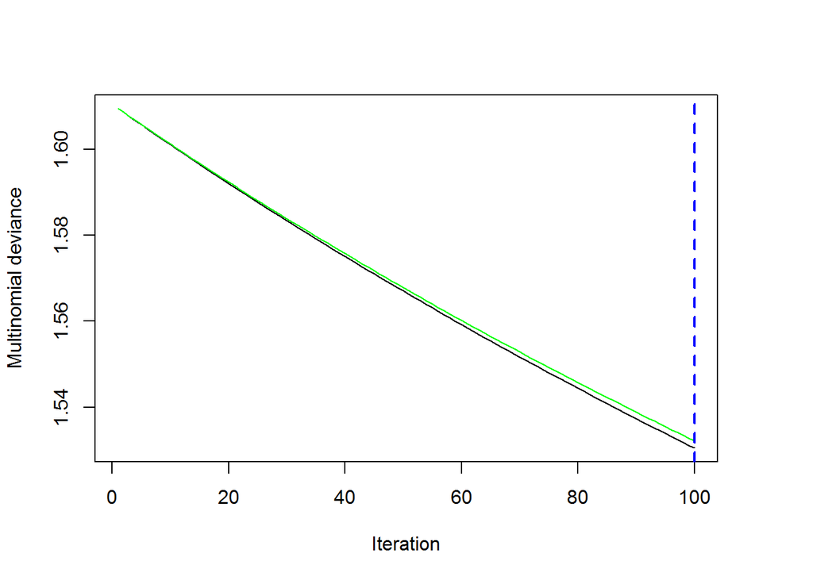

```r
pred<-predict(gbm1, testing, best.iter ,type='response')
pred_class <- apply(pred, 1, which.max)
pred_class[pred_class==1]<-"A"
pred_class[pred_class==2]<-"B"
pred_class[pred_class==3]<-"C"
pred_class[pred_class==4]<-"D"
pred_class[pred_class==5]<-"E"

confusionMatrix(testing$classe,pred_class)
```

```
## Confusion Matrix and Statistics
##
##           Reference
## Prediction    A    B    C    D    E
##          A 3202  111 1199  438   72
##          B 1016 1280  904  217    0
##          C  580  132 2033  334    0
##          D  707  158  869 1160    0
##          E  599  472  526  103 1546
##
## Overall Statistics
##
##                Accuracy : 0.5222
##                  95% CI : (0.5148, 0.5296)
##     No Information Rate : 0.3457
##     P-Value [Acc > NIR] : < 2.2e-16
##
##                   Kappa : 0.3919
##  Mcnemar's Test P-Value : < 2.2e-16
##
## Statistics by Class:
##
##                      Class: A Class: B Class: C Class: D Class: E
## Sensitivity            0.5246  0.59452   0.3676  0.51510  0.95550
## Specificity            0.8425  0.86217   0.9137  0.88745  0.89401
## Pos Pred Value         0.6376  0.37460   0.6603  0.40083  0.47628
## Neg Pred Value         0.7703  0.93870   0.7601  0.92604  0.99500
## Prevalence             0.3457  0.12193   0.3132  0.12753  0.09163
## Detection Rate         0.1813  0.07249   0.1151  0.06569  0.08755
## Detection Prevalence   0.2844  0.19351   0.1744  0.16389  0.18383
## Balanced Accuracy      0.6835  0.72835   0.6407  0.70127  0.92476
```

Conclusion of accuracy

To conclude the best model to developp is Randomforest

# 3) Random forest study

We extend the study by enlarging the training file and increasing the number of trees

```r
inTrain2<-createDataPartition(y=pml1$classe, p=0.7, list = FALSE)
training2<-pml1[inTrain2,]
testing2<-pml1[-inTrain2,]

set.seed(25)
modfit5<-randomForest(classe ~., data = training2, ntree = 1000, mtry = 35 )
confusionMatrix(testing2$classe,predict(modfit5,testing2))
```

```
## Confusion Matrix and Statistics
##
##           Reference
## Prediction    A    B    C    D    E
##          A 1673    0    0    0    1
##          B    5 1130    3    1    0
##          C    0    3 1019    4    0
##          D    1    2   20  941    0
##          E    0    0    0    2 1080
##
## Overall Statistics
##
##                Accuracy : 0.9929
##                  95% CI : (0.9904, 0.9949)
##     No Information Rate : 0.2853
##     P-Value [Acc > NIR] : < 2.2e-16
##
##                   Kappa : 0.991
##  Mcnemar's Test P-Value : NA
##
## Statistics by Class:
##
##                      Class: A Class: B Class: C Class: D Class: E
## Sensitivity            0.9964   0.9956   0.9779   0.9926   0.9991
## Specificity            0.9998   0.9981   0.9986   0.9953   0.9996
## Pos Pred Value         0.9994   0.9921   0.9932   0.9761   0.9982
## Neg Pred Value         0.9986   0.9989   0.9953   0.9986   0.9998
## Prevalence             0.2853   0.1929   0.1771   0.1611   0.1837
## Detection Rate         0.2843   0.1920   0.1732   0.1599   0.1835
## Detection Prevalence   0.2845   0.1935   0.1743   0.1638   0.1839
## Balanced Accuracy      0.9981   0.9968   0.9882   0.9940   0.9993
```

The selection of random forest algorithm show no need to perform a cross validation (it’s include in the algorithm)

Finaly we get an accuracy of 99.3% which is very good for this type of exercise

# 4) final test on the 20 samples

We use the same preprocessing as the training test set (suppression of columns) and use the predict function on the final model (modfit5)

```r
pmltest<- read.csv("pml-testing.csv",header = TRUE, sep = ",", stringsAsFactors = TRUE, dec = ".", na.strings=c("NA", ""))
pmltest2<-pmltest[,Nacol[]==0]
pmltest2<-pmltest2[,8:ncol(pmltest2)]

answers<-predict(modfit5,pmltest2)

pml_write_files = function(x){
        n = length(x)
        for(i in 1:n){
                filename = paste0("problem_id_",i,".txt")
                write.table(x[i],file=filename,quote=FALSE,row.names=FALSE,col.names=FALSE)
        }
}
pml_write_files(answers)
```

20/20 on assessment !